# Projet économétrie

Louise Albarran et Eloise Sibottier

2025-11-27

# **1 Introduction**

# **2 Cadre méthodologique**

# **3 Analyse des données**

## **3.1 Cadre des données**

Cette étude s’appuie sur une base de données de départ regroupant des variables économiques, sociales, démographiques et environnementales.

Le tableau ci-dessous récapitule les variables candidates utilisées dans le modèle, avec leur définition, unité et source.

| Code | Définition synthétique | Unité | Source |
| --- | --- | --- | --- |
| **Mort_inf** | Taux de mortalité infantile (décès <1 an / naissances vivantes, 2021–2023) | ‰ (pour 1 000) | INSEE – État civil |
| **tx_chom** | Taux de chômage annuel moyen (15–64 ans) | % | INSEE – RP |
| **Prest_fami** | Part des prestations familiales dans le revenu disponible | % | INSEE – Filosofi |
| **Med_niv_vie** | Niveau de vie médian | € | INSEE – Filosofi |
| **Pas_diplo** | Part des non/peu diplômés (15 ans ou +, non scolarisés) | % | INSEE – RP |
| **Dens_pop** | Densité de population | hab./km² | INSEE – RP |
| **Tx_pauvrete** | Taux de pauvreté | % | INSEE – Filosofi |
| **Part_pop_eloignee** | Population éloignée des services (>20 min d’un soin) | % | Obs. Territoires – BPE |
| **monoparentales** | Part des familles monoparentales | % | INSEE – RP |
| **trois_enfants** | Part des familles avec ≥3 enfants | % | INSEE – RP |
| **tx_pauv_monoparentales** | Taux de pauvreté des familles monoparentales | % | INSEE – Filosofi |
| **Part_RSA** | Allocataires RSA pour 1 000 habitants (15–64 ans) | ‰ (pour 1000) | CNAF – FILEAS |
| **Part_ALF** | Bénéficiaires allocation logement familiale | % | CNAF – BENTRIM/FILEAS |
| **Gaz_effet_serre** | Émissions de GES par habitant | tonnes (CO₂ par habitant) , | Citepa 2021 |
| **Eff_fonc_publique_terr** | Effectif de la fonction publique territoriale pour 1 000 habitants | ‰ (pour 1 000) | INSEE – SIASP |
| **part_ouvrier** | Part d’ouvriers dans les emplois au lieu de travail | % | INSEE – RP |
| **part_cadre** | Part de cadres et profs. intellectuelles | % | INSEE – RP |
| **part_cadre_ind** | Variable indicatrice (1 = cadre, 0 = non-cadre) | 0/1 | Construction propre |
| **APL_gene** | Accessibilité potentielle localisée aux médecins généralistes | consultations accessibles / habitant | DREES – SNIIR-AM |
| **APL_sages_femmes** | Accessibilité potentielle localisée sages-femmes | ETP / 100 000 habitants | DREES – SNIIR-AM |

## **3.2 Prétraitement et nettoyage des données**

Du fait que les variables sont nombreuses elles sont rassemblés en trois catégories (Précarité et vulnérabilités socio-économiques, Structure familiale et structure professionnelle, Structure familiale et structure professionnelle) pour faciliter la lecture et les statiques descriptibes.

## **3.3 Analyse descriptive univariée des données**

L’analyse univariée a été réalisée par catégorie pour examiner la distribution de chaque variable (histogrammes), permettant ainsi de détecter d’éventuels problèmes de distribution, d’hétéroscédasticité ou la présence d’outliers.

### A) Précarité et vulnérabilités socio-économiques

|  | Mean | SD | Min | Median | Max |
| --- | --- | --- | --- | --- | --- |
| tx_chom | 7.71 | 1.87 | 4.30 | 7.35 | 18.00 |
| Tx_pauvrete | 15.22 | 3.88 | 9.10 | 14.85 | 36.10 |
| Pas_diplo | 20.63 | 3.68 | 11.50 | 20.65 | 34.90 |
| Part_RSA | 4.25 | 2.17 | 1.70 | 3.83 | 17.33 |
| Part_ALF | 9.99 | 4.14 | 4.40 | 9.80 | 32.90 |
| tx_pauv_monoparentales | 30.41 | 4.86 | 19.70 | 29.70 | 53.90 |
| Prest_fami | 1.90 | 0.43 | 0.70 | 1.90 | 4.10 |

### B) Structure familiale et professionnelle

|  | Mean | SD | Min | Median | Max |
| --- | --- | --- | --- | --- | --- |
| monoparentales | 16.28 | 4.08 | 10.30 | 15.35 | 42.80 |
| trois_enfants | 8.01 | 2.20 | 4.50 | 7.60 | 17.30 |
| Med_niv_vie | 22619.18 | 1820.03 | 17070.00 | 22230.00 | 29730.00 |
| part_ouvrier | 21.67 | 4.32 | 7.30 | 21.50 | 29.90 |
| part_cadre | 15.17 | 6.27 | 9.30 | 13.15 | 47.70 |

### C) Accès au logement, services localisés et environnement

|  | Mean | SD | Min | Median | Max |
| --- | --- | --- | --- | --- | --- |
| APL_gene | 3.15 | 0.66 | 2.00 | 3.00 | 4.70 |
| APL_sages_femmes | 21.67 | 5.03 | 9.90 | 22.20 | 38.10 |
| Part_pop_eloignee | 1.77 | 2.89 | 0.00 | 0.70 | 19.10 |
| Dens_pop | 561.95 | 2375.89 | 14.80 | 86.05 | 20054.10 |
| Gaz_effet_serre | 6.86 | 2.46 | 2.19 | 6.40 | 16.94 |
| Eff_fonc_publique_terr | 29.92 | 5.51 | 19.22 | 29.04 | 56.61 |

En examinant le résumé des données, certains résultats attire notre attention et montrent des situations très extrêmes pour plusieurs variables. Par exemple :

- La part de population éloignée des services atteint 19 % à Lorèze, alors que le troisième quartile n’est que de 1,75 %.
- La part des bénéficiaires du RSA culmine à 17,33 % à La Réunion contre 4,66 % pour le troisième quartile.
- La part des bénéficiaires ALF est de 32 % à La Réunion, alors que Q3 = 11,45 %.
- La part des cadres atteint 47,70 % dans les Hauts-de-Seine, contre 16,40 % pour Q3.
- La part des familles monoparentales atteint 42,80 % en Martinique, contre 17 % pour Q3.
- Enfin, la densité de population présente une forte hétéroscédasticité, avec des valeurs très variables entre départements.

Ces observations mettent en évidence la présence de valeurs extrêmes qui pourraient avoir un poids disproportionné dans l’analyse. Elles suggèrent que certaines variables pourraient bénéficier d’une transformation logarithmique pour plusieurs raisons :

- **Réduire l’impact des outliers :** les individus atypiques sont « compressés », ce qui limite leur influence excessive sur les modèles de régression.
- **Resserer les distributions :** les variables très asymétriques deviennent plus homogènes et plus proches d’une forme symétrique.
- **Améliorer la robustesse des estimations :** la linéarité et l’homoscédasticité sont mieux respectées, ce qui rend les résultats des modèles multivariés plus fiables.

Cette première observation justifie donc de considérer un passage en logarithme pour plusieurs variables, mais la décision finale sera confirmée avec la suite de notre analyse descriptive, afin de vérifier que la transformation améliore réellement la structure des données et la qualité des modèles.

### A) Précarité et vulnérabilités socio-économiques

Les histogrammes montrent une forte asymétrie vers la droite : la majorité des départements se situe sur des valeurs faibles, mais quelques observations très élevées, souvent des départements d’outre-mer ou des zones particulièrement touchées par la précarité, tirent la distribution vers l’extrémité droite. Ces valeurs extrêmes peuvent empecher de considerer ces variables comme suivant une loi normale.

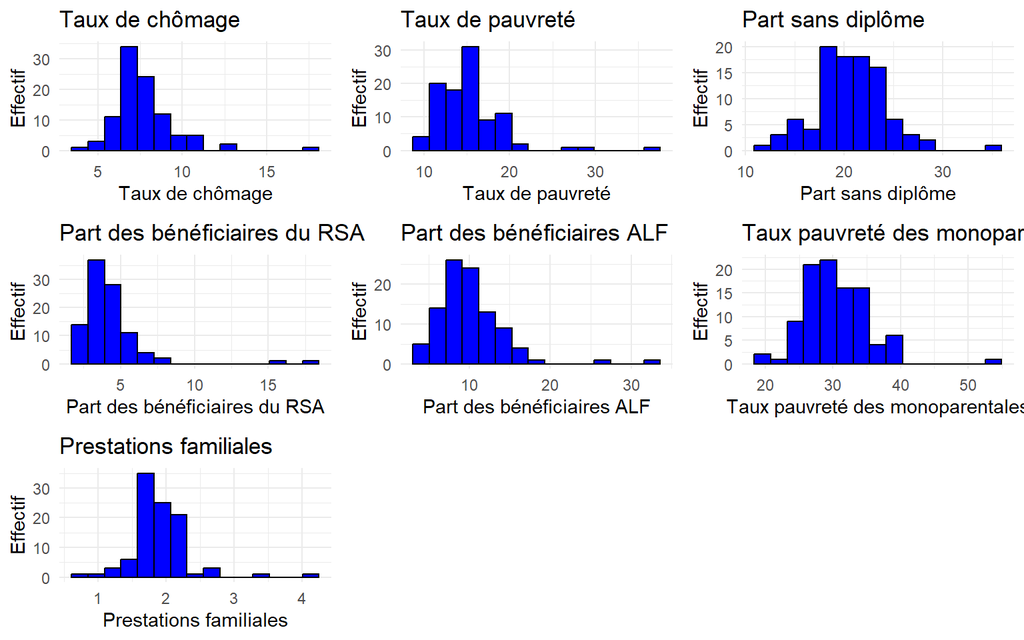

### B) Structure familiale et structure professionnelle

Dans la catégorie « structure familiale et professionnelle », les histogrammes confirment aussi la domination d’outliers à droite pour la plupart des variables, à l’exception notable de la part des ouvriers qui présente une répartition beaucoup plus homogène et moins « extrême ».

La part des familles monoparentales et le niveau de vie médian sont quant à eux fortement concentrés autour d’une valeur centrale, montrant une leptokurticité : forte concentration autour de la moyenne et queues relativement fines. Ces observations indiquent que la plupart des départements sont assez proches les uns des autres pour certaines mesures, mais quelques-uns se distinguent par des valeurs beaucoup plus élevées ou plus faibles.

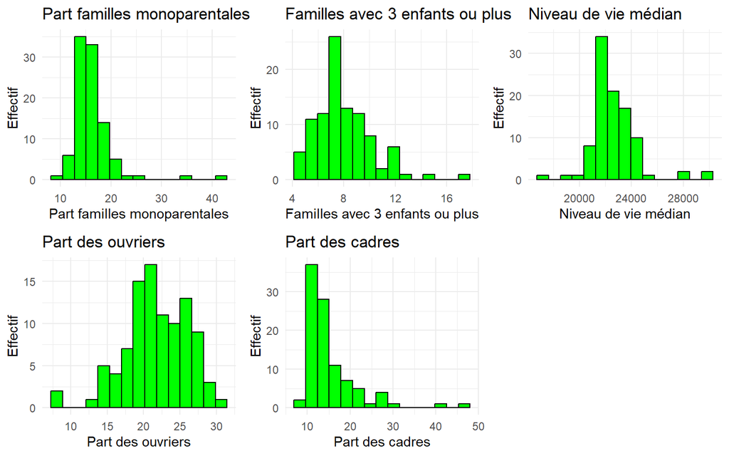

### C) Accès au logement, services localisés et environnement

Pour la troisième catégorie « accès au logement, services localisés et environnement », les histogrammes offrent un panorama hétérogène.

La variable APL généraliste ne révèle pas d’outliers marqués mais sa distribution est manifestement non gaussienne, avec une forme irrégulière et des amas de valeurs sur certaines plages ; elle reste donc incompatible avec l’hypothèse de normalité.

La proportion de population éloignée des services (>20 minutes) est fortement concentrée sur des petites valeurs mais présente un outlier très marqué à droite, ce qui crée une queue asymétrique importante.

La densité de population est massivement concentrée à gauche (beaucoup de départements faiblement denses) et ponctuée par quelques territoires très denses qui forment une longue queue droite ; ce profil est typique des variables géographiques et confirme la nécessité d’un traitement particulier (passage en log)

Enfin, les émissions de gaz à effet de serre et les effectifs de la fonction publique territoriale ont des histogrammes qui s’apparentent davantage à une forme proche d’une distribution « raisonnablement centrée », mais la normalité n’est pas parfaite : ces deux variables restent seulement relativement plus régulières que les autres, sans pouvoir être considérées comme strictement gaussiennes.

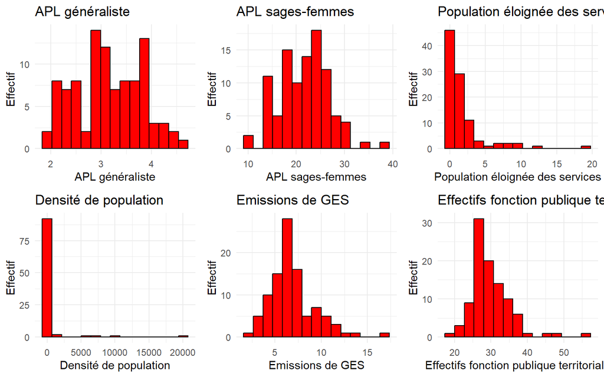

## **3.4 Analyse descriptive bivariée des données**

### A) Corrélation entre la variables à expliqués et les variables explicatives

L’analyse bivariée a pour objectif d’évaluer la corrélation linéaire entre la variable dépendante ($Y$: Taux de mortalité infantile) et chacune des variables explicatives ($X$).

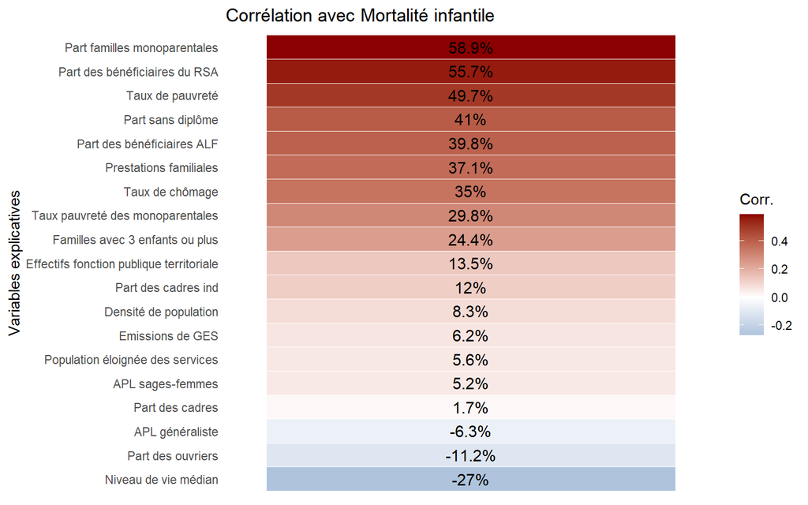

Les corrélations les plus fortes sont observées avec les variables liées à la précarité et à la structure familiale, notamment la Part des familles monoparentales (58.9%) et la Part des bénéficiaires du RSA (55.7%). Les nuages de points confirment graphiquement ces relations.

### A.1) Précarité et vulnérabilités socio-économiques

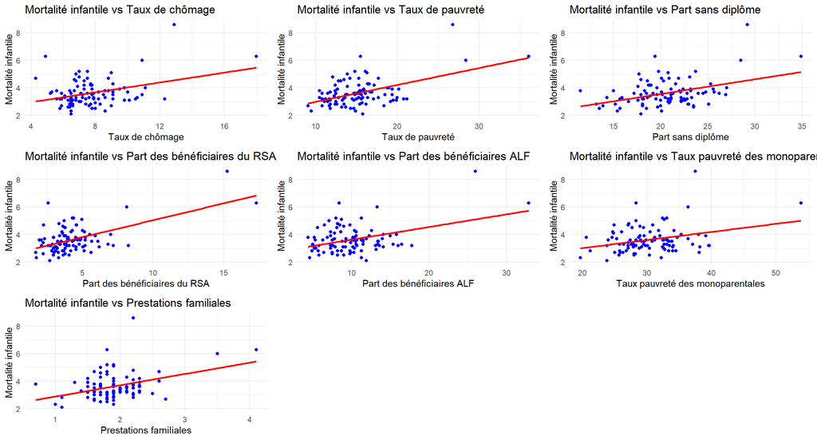

L’analyse des nuages de points de la première catégorie fait apparaître des relations clairement linéaires et positives entre la mortalité infantile et l’ensemble des indicateurs de précarité.

Plus le taux de pauvreté, la part des bénéficiaires du RSA, la part sans diplôme ou encore le taux de pauvreté des familles monoparentales augmentent, plus la mortalité infantile tend à s’élever.

Toutefois, la présence d’outliers, souvent situés très à droite du nuage, vient perturber l’ajustement linéaire : ces observations extrêmes peuvent accentuer artificiellement la pente et doivent être prises en compte avec prudence lors de l’interprétation. Malgré ces valeurs atypiques, nous pouvons émettre l’hypothèse que la précarité économique et sociale est fortement associée à une hausse de la mortalité infantile.

### A.2) Structure familiale et structure professionnelle

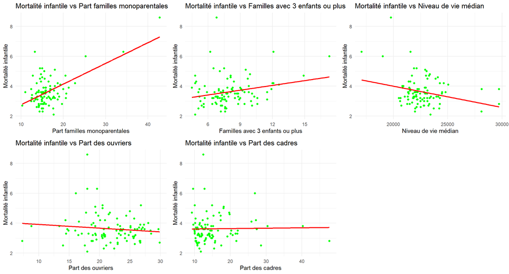

La seconde catégorie présente un comportement plus nuancé. Certaines variables y montrent des relations très fortes, d’autres beaucoup plus faibles.

La part des familles monoparentales est celle qui se distingue le plus clairement : son nuage de points laisse apparaître une relation positive nette, ce qui est cohérent avec le fait qu’il s’agit de la variable présentant la corrélation la plus élevée avec la mortalité infantile. Là encore, quelques outliers influencent la pente, notamment des départements ultra-marins ou à structure familiale très particulière, mais la tendance globale reste solide.

La part des familles avec trois enfants ou plus semble elle aussi liée positivement à la mortalité infantile, même si l’effet est visuellement plus faible et plus diffus.

À l’inverse, le niveau de vie médian montre une relation légèrement négative : les départements plus aisés tendent à connaître une mortalité infantile plus faible, ce qui est intuitif, même si la pente demeure modérée.

Un résultat surprenant apparaît pour la part des ouvriers : la relation avec la mortalité infantile est faible, mais elle est négative, ce qui est contre‑intuitif. Alors que l’on observe généralement que les situations socio‑économiques défavorables sont associées à une mortalité infantile plus élevée, ici, les départements avec une part plus importante d’ouvriers semblent légèrement avoir une mortalité infantile plus faible. Cette observation est difficile à expliquer.

Enfin, la part des cadres ne laisse apparaître pratiquement aucune relation visuelle avec la mortalité infantile : le nuage est dispersé, sans tendance nette, ce qui indique que cette variable n’exerce pas d’influence directe identifiable dans ce cadre purement bivarié.

### A.3) Accès au logement, services localisés et environnement

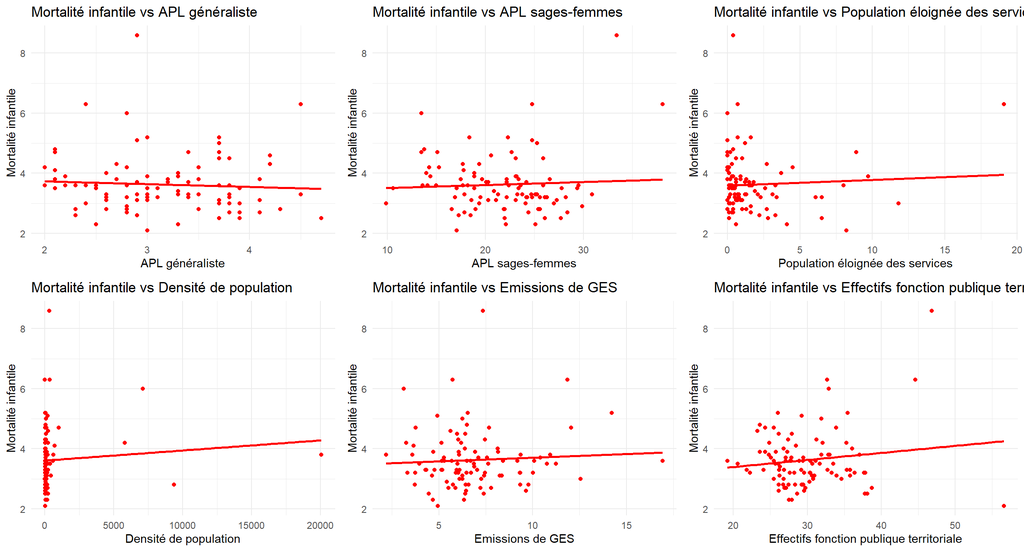

La troisième catégorie, regroupant l’accès aux services, des indicateurs d’environnement et des mesures territoriales, est de loin celle qui présente les relations les plus faibles avec la mortalité infantile. La plupart des nuages de points sont largement dispersés, sans forme particulière ni pente identifiable.

Les variables comme l’APL généraliste, l’APL sages-femmes ou la population éloignée des services ne montrent presque aucune structure linéaire : les points sont répartis de manière diffuse, ce qui suggère une absence de relation directe.

Quelques éléments se détachent néanmoins légèrement : la densité de population semble présenter une pente positive faible, indiquant que la mortalité infantile pourrait être un peu plus élevée dans les territoires très denses, mais l’effet reste visuellement très limité.

De manière surprenante, les effectifs de la fonction publique territoriale par 1000 habitants montrent une légère relation positive avec la mortalité infantile : plus il y a de fonctionnaires par habitant, plus la mortalité infantile semble élevée. Ce résultat est contre‑intuitif et ne traduit probablement pas un lien de cause à effet direct, mais pourrait refléter des facteurs confondants liés à la situation sociale ou économique de certains départements.

Dans l’ensemble, les nuages de points confirment que les variables les plus fortement associées à la mortalité infantile appartiennent presque exclusivement au champ socio-économique.

Les structures familiales jouent également un rôle important, mais les variables liées aux services et à l’environnement apparaissent beaucoup moins pertinentes dans leur forme brute. Cette analyse bivariée permet ainsi d’identifier les déterminants les plus robustes avant la construction du modèle multivarié.

### B) Transformation des variables : Passage en log

Lors de l’analyse des distributions, nous avons constaté que plusieurs variables présentaient :

une forte asymétrie à droite (une majorité de départements concentrée sur des valeurs faibles et quelques valeurs extrêmes très élevées) ;

la présence d’outliers susceptibles d’influencer de manière excessive les estimations de régression.

Pour limiter ces effets et se rapprocher des conditions nécessaires à une régression linéaire fiable (linéarité et homogénéité de la variance), nous avons appliqué une transformation logarithmique sur certaines variables.

Cette transformation a plusieurs avantages :

Réduire l’impact des valeurs extrêmes : les outliers deviennent moins influents, ce qui évite de fausser les coefficients de régression.

Rapprocher la distribution de la normalité : les variables très asymétriques deviennent plus symétriques et plus « resserrées » autour de la moyenne.

Améliorer la stabilité des estimations : les modèles multivariés produisent des résultats plus robustes et fiables.

Les variables concernées incluent notamment :

- Densité de population
- Part de population éloignée des services
- Part des bénéficiaires du RSA
- Part des bénéficiaires ALF
- Part des cadres
- Part des familles monoparentales

## **3.5 Gestion de la Multicolinéarité et Sélection du Modèle**

Pour sélectionner un modèle final cohérent, plusieurs critères ont été mobilisés simultanément, en s’appuyant uniquement sur les résultats produits dans l’analyse :

- **Corrélations :** (seuil : |r| > 0,8)
- **Règle de Klein :** r²(Xᵢ, Xⱼ) > R²(modèle complet) → multicolinéarité problématique
- **VIF :** seuil critique > 10
- **Cohérence des signes :** les coefficients doivent aller dans le même sens que les relations bivariées

Ces éléments ont permis d’établir une procédure de réduction du modèle en trois itérations successives.

### A) Premier modèles avec toutes les variables

```
##
## Résultats de la Régression Linéaire
## ==================================================
##                            Dependent variable:
##                        ---------------------------
##                                 Mort_inf
## --------------------------------------------------
## tx_chom                          -0.152
##                                  (0.138)
##
## Prest_fami                        0.600
##                                  (0.640)
##
## Med_niv_vie                      0.0001
##                                 (0.0002)
##
## Pas_diplo                         0.032
##                                  (0.064)
##
## Tx_pauvrete                     0.310***
##                                  (0.107)
##
## APL_gene                         -0.098
##                                  (0.171)
##
## APL_sages_femmes                 0.048**
##                                  (0.020)
##
## trois_enfants                    -0.071
##                                  (0.125)
##
## tx_pauv_monoparentales          -0.238***
##                                  (0.071)
##
## Gaz_effet_serre                  0.101**
##                                  (0.049)
##
## Eff_fonc_publique_terr           -0.026
##                                  (0.019)
##
```

[output cut: 20 more lines]

```
##
## log_monoparentales                0.822
##                                  (1.244)
##
## Constant                          3.549
##                                  (5.699)
##
## --------------------------------------------------
## Observations                       98
## R2                                0.550
## Adjusted R2                       0.440
## Residual Std. Error          0.718 (df = 78)
## F Statistic              5.019*** (df = 19; 78)
## ==================================================
## Note:                  *p<0.1; **p<0.05; ***p<0.01
```

### B) Itération 1 : Modèle Complet (Reg1)

Nous commençons par estimer le modèle incluant toutes les variables (Reg1) pour évaluer la multicolinéarité initiale.

Le premier modèle comprenait toutes les variables transformées et non transformées. L’analyse de la multicolinéarité a immédiatement mis en évidence plusieurs corrélations supérieures à 80 %, principalement autour des variables socio-économiques :

- Part RSA ↔︎ Taux de chômage (85,8 %)
- Taux de chômage ↔︎ Taux de pauvreté (84,8 %)
- Taux de chômage ↔︎ Taux de pauvreté des monoparentales (80,6 %)
- Taux de pauvreté ↔︎ Taux de pauvreté des monoparentales (81,4 %)
- Densité ↔︎ Part de cadres (84,9 %)
- Part de cadres ↔︎ Part_cadre_ind (82,2 %)

Plusieurs paires ne suivaient pas également la règle de Klein, avec des r² supérieurs au R² du modèle complet (0,55). C’était notamment le cas pour :

- taux de chômage avec pauvreté, pauvreté monoparentale, part RSA et part de familles monoparentales
- niveau de vie médian avec pas de diplôme et pauvreté monoparentale
- densité avec population éloignée et part de cadres
- part de pauvreté avec part RSA, part ALF, monoparentales et taux de pauvreté monoparentales
- Part des familles monoparentales avec part RSA
- Taux de pauvreté monoparentales avec la part des bénéficiaires du RSA
- La part des ouvriers avec la part des cadres
- part de cadres avec l’indicatrice de la part des cadres

Les VIF confirmaient ces problèmes, avec des valeurs extrêmement élevées : 32 pour le taux de pauvreté, 22 pour la pauvreté monoparentale, plus de 18 pour la part de cadres, plus de 14 pour trois enfants, plus de 12 pour le taux de chômage.

Enfin, certaines variables présentaient une incohérence entre le signe attendu (corrélation bivariée) et le signe estimé dans le modèle.

À ce stade, nous avons supprimé :

- Taux de chômage, très fortement corrélé à d’autres variables de précarité et ne respectant pas la cohérence des signes.
- Niveau de vie médian, corrélé à pas de diplôme et pauvreté monoparentale, et dont le signe ne correspondait pas aux attentes.
- Densité de population et part des cadres, très corrélées entre elles et avec des signes incohérents.
- Part RSA, fortement corrélée à monoparentales.
- Taux de pauvreté, corrélé à RSA, ALF, chômage, monoparentales, et présentant un VIF particulièrement élevé.

Après ces suppressions, un second modèle a été estimé.

### C) Itération 2 : Modèle Intermédiaire (Reg2)

Un nouveau modèle (Reg2) est estimé après la suppression des variables identifiées dans la première itération.

Dans ce deuxième modèle, des corrélations élevées subsistaient, notamment entre :

- part de cadres ↔︎ part_cadre_ind (82 %)
- pas de diplôme ↔︎ pauvreté monoparentale (r² = 0,517)
- pas de diplôme ↔︎ prestations familiales (r² = 0,462)
- part population éloignée ↔︎ trois enfants (r² = 0,461)
- pauvreté monoparentale ↔︎ ALF (r² = 0,53)

Les incohérences de signes étaient encore présentes, notamment pour trois enfants, pauvreté monoparentale, ALF, effectif fonction publique territoriale et part de cadres.

Les VIF restaient problématiques pour trois enfants (10), part ouvriers (8,7), prestations familiales (8,2), part de cadres (13,2).

À ce stade, ont été supprimés :

- Pas de diplôme, en raison qu’il ne respecte pas la règle de Klein avec pauvreté monoparentale et prestations familiales.
- Trois enfants, en raison d’une incohérence du signe et d’une corrélation élevée avec la population éloignée.
- taux de pauvreté monoparentales trop corrélés a part des ALF

Un troisième modèle a alors été estimé.

### D) Itération 3 :

Le dernier modèle n’affichait plus de corrélations supérieures à 80 %. Quelques paires restaient légèrement au-dessus du seuil de Klein, mais sans impact suffisant pour nécessiter de nouvelles suppressions. Les VIF étaient largement revenus dans des ordres de grandeur acceptables, et tous les coefficients conservaient des signes cohérents.

Ce modèle constituait une base suffisamment stable pour procéder à une sélection finale par critère AIC. L’élimination successive des variables les moins informatives a conduit à un modèle final plus parcimonieux, conservant uniquement les prédicteurs présentant un effet robuste, significatif ou économiquement cohérent.

## **3.6 Modele final**

Cette section présente le modèle économétrique retenu pour l’analyse de la mortalité infantile. Conformément à la démarche empirique adoptée, deux spécifications sont distinguées. La sous‑partie A présente le modèle de référence estimé sans variable indicatrice, tandis que la sous‑partie B introduit une variable indicatrice afin de tester l’existence d’un effet de seuil, dans un objectif à la fois analytique et pédagogique.

### A) Modele sans indicatrice

Afin d’assurer la robustesse de la spécification retenue et d’éviter une dépendance excessive à une seule procédure algorithmique, trois méthodes de sélection des variables explicatives sont mobilisées : une sélection ascendante (forward), une sélection descendante (backward) et une sélection mixte (stepwise).

La procédure de sélection ascendante (forward) consiste à partir d’un modèle restreint ne contenant que la constante, puis à introduire successivement les variables explicatives. À chaque étape, les variables candidates sont testées individuellement, et celle dont l’introduction améliore le plus le critère d’information d’Akaike est retenue. Le processus se poursuit de manière itérative, en ajoutant à chaque étape la variable qui maximise le gain informationnel, jusqu’à ce qu’aucune nouvelle variable ne permette d’améliorer le critère. Cette méthode privilégie ainsi une construction progressive du modèle, guidée par la contribution marginale de chaque facteur explicatif.

À l’inverse, la procédure de sélection descendante (backward) débute à partir d’un modèle saturé intégrant l’ensemble des variables explicatives candidates. Les variables sont ensuite retirées une à une, en commençant par celle dont la suppression améliore le plus le critère d’Akaike. Le processus d’élimination se poursuit jusqu’à ce que le retrait d’aucune variable supplémentaire ne permette d’améliorer le critère. Cette approche est particulièrement adaptée lorsque le nombre de variables candidates est élevé et permet de contrôler plus directement le risque de variables omises.

La procédure mixte (stepwise) combine les deux logiques précédentes. Elle autorise à la fois l’introduction et le retrait de variables à chaque étape, en fonction de l’évolution du critère d’information. Dans le cas présent, la procédure stepwise conduit à la même spécification finale que la procédure backward. Cette convergence s’explique par la structure des données et par le fait que les variables retenues dans le modèle final présentent une contribution informationnelle suffisamment forte pour ne pas être remises en cause lors des étapes successives d’ajout ou de retrait.

**Comparaison des Modèles de Régression Linéaire**

|  | *Dependent variable:* |  |  |
| --- | --- | --- | --- |
|  | Mortalité Infantile |  |  |
|  | Modèle Backward | Modèle Forward | Modèle Mixte |
|  | (1) | (2) | (3) |
| APL généraliste |  | -0.168 |  |
|  |  | (0.153) |  |
| APL sages-femmes |  | 0.016 |  |
|  |  | (0.020) |  |
| Log(Population éloignée des services) |  | -0.039 |  |
|  |  | (0.087) |  |
| Log(Part familles monoparentales) | 2.790*** | 3.043*** | 2.790*** |
|  | (0.481) | (0.746) | (0.481) |
| Prestations familiales | 0.346* | 0.279 | 0.346* |
|  | (0.201) | (0.255) | (0.201) |
| Log(Part des bénéficiaires ALF) |  | -0.131 |  |
|  |  | (0.335) |  |
| Émissions de GES | 0.108*** | 0.119*** | 0.108*** |
|  | (0.036) | (0.043) | (0.036) |
| Effectifs fonction publique territoriale |  | -0.005 |  |
|  |  | (0.019) |  |
| Part des ouvriers |  | 0.002 |  |
|  |  | (0.033) |  |
| Constant | -5.496*** | -5.550** | -5.496*** |
|  | (1.350) | (2.127) | (1.350) |
| Observations | 98 | 98 | 98 |
| R<sup>2</sup> | 0.366 | 0.380 | 0.366 |
| Adjusted R<sup>2</sup> | 0.345 | 0.317 | 0.345 |
| Residual Std. Error | 0.777 (df = 94) | 0.794 (df = 88) | 0.777 (df = 94) |
| F Statistic | 18.066*** (df = 3; 94) | 5.996*** (df = 9; 88) | 18.066*** (df = 3; 94) |
| *Note:* | p<0.1; p<0.05; p<0.01 |  |  |

Les résultats des trois procédures montrent une grande cohérence dans les variables retenues. En particulier, les variables log_monoparentales, Prest_fami et Gaz_effet_serre apparaissent significatives dans le modèle backward et dans le modèle mixte. L’examen des signes des coefficients associés à ces variables indique une conformité avec les attentes théoriques. Une augmentation de la proportion de familles monoparentales est associée à une hausse de la mortalité infantile, ce qui est cohérent avec la littérature mettant en évidence le rôle des conditions socio-économiques défavorables. De même, une part plus élevée de bénéficiaires de prestations familiales est positivement associée à la mortalité infantile, ce qui peut s’interpréter comme un indicateur indirect de vulnérabilité économique des territoires. Enfin, l’effet positif des émissions de gaz à effet de serre sur la mortalité infantile est conforme aux hypothèses issues de la littérature en économie de la santé et en économie de l’environnement.

À ce stade, l’analyse se limite volontairement à une vérification de la cohérence des signes et de la significativité statistique des coefficients. Une interprétation économique approfondie de ces résultats sera développée dans une section ultérieure consacrée à l’analyse détaillée des déterminants de la mortalité infantile.

En termes de qualité d’ajustement, le modèle forward présente un coefficient de détermination légèrement supérieur (R² = 0,380) à celui du modèle backward et du modèle mixte (R² = 0,366). Toutefois, le modèle backward est retenu comme modèle de référence, dans la mesure où il conserve une variable explicative statistiquement significative supplémentaire par rapport au modèle forward, tout en présentant un R² ajusté très proche. Ce choix privilégie une spécification plus riche sur le plan explicatif, sans dégradation substantielle de la qualité d’ajustement, et constitue ainsi un compromis pertinent entre parcimonie et pouvoir explicatif.

### B) Choix de l’indicatrice dans le modele final

Il est difficile d’identifier une variable indicatrice naturelle permettant d’expliquer la mortalité infantile à l’échelle départementale en France. Les facteurs qui influencent la mortalité infantile sont le plus souvent continus et ne se prêtent pas facilement à une catégorisation binaire. Dans ce contexte, l’introduction d’une variable indicatrice dans le modèle ne vise pas à améliorer la qualité de l’estimation, mais répond avant tout à un objectif pédagogique.

Les variables indicatrices ainsi construites ont ensuite été introduites une à une dans le modèle backward retenu précédemment. À chaque étape, les tests de significativité ont été réestimés afin d’évaluer l’apport de chaque indicatrice. Cette procédure permet d’éviter l’introduction simultanée de plusieurs indicatrices et de limiter les problèmes de sur-paramétrisation.

**Comparaison des modèles de régression linéaire (AIC)**

|  | *Dependent variable:* |  |  |
| --- | --- | --- | --- |
|  | Mortalité Infantile |  |  |
|  | Modèle Backward | Modèle Forward | Modèle Mixte |
|  | (1) | (2) | (3) |
| APL généraliste |  | -0.176 |  |
|  |  | (0.151) |  |
| APL sages-femmes |  | 0.011 |  |
|  |  | (0.019) |  |
| Log(Population éloignée des services) |  | -0.059 |  |
|  |  | (0.086) |  |
| Log(Part familles monoparentales) | 2.930*** | 3.024*** | 2.930*** |
|  | (0.481) | (0.734) | (0.481) |
| Prestations familiales | 0.334* | 0.282 | 0.334* |
|  | (0.198) | (0.251) | (0.198) |
| Log(Part des bénéficiaires ALF) |  | -0.053 |  |
|  |  | (0.332) |  |
| Émissions de GES | 0.189*** | 0.222*** | 0.189*** |
|  | (0.056) | (0.067) | (0.056) |
| Effectifs fonction publique territoriale |  | -0.010 |  |
|  |  | (0.019) |  |
| Part des ouvriers |  | -0.013 |  |
|  |  | (0.033) |  |
| Gaz_effet_serre_Q3 | -0.539* | -0.626** | -0.539* |
|  | (0.293) | (0.314) | (0.293) |
| Constant | -6.273*** | -5.634*** | -6.273*** |
|  | (1.398) | (2.093) | (1.398) |
| Observations | 98 | 98 | 98 |
| R<sup>2</sup> | 0.388 | 0.407 | 0.388 |
| Adjusted R<sup>2</sup> | 0.362 | 0.339 | 0.362 |
| Residual Std. Error | 0.767 (df = 93) | 0.781 (df = 87) | 0.767 (df = 93) |
| F Statistic | 14.740*** (df = 4; 93) | 5.976*** (df = 10; 87) | 14.740*** (df = 4; 93) |
| *Note:* | p<0.1; p<0.05; p<0.01 |  |  |

À l’issue de ces tests, une seule variable indicatrice apparaît significative : l’indicatrice associée aux émissions de gaz à effet de serre, notée Gaz_effet_serre_Q3. Son coefficient est négatif (−0,539) et significatif au seuil de 10 %. Ce signe indique que, toutes choses égales par ailleurs, les départements appartenant au quartile supérieur des émissions de gaz à effet de serre présentent un niveau de mortalité infantile inférieur à celui prédit par un modèle strictement linéaire.

Ce résultat suggère l’existence possible d’une relation non linéaire entre pollution environnementale et mortalité infantile. Toutefois, compte tenu du caractère arbitraire du seuil retenu et de la perte d’information liée à la transformation d’une variable continue en indicatrice, cette interprétation doit rester prudente. Une analyse plus détaillée de ce résultat sera proposée dans la partie suivante.

### C) Modele final

Après avoir mis en évidence l’existence d’un effet de seuil environnemental à travers l’introduction de la variable indicatrice Gaz_effet_serre_Q3, il est naturel de s’interroger sur la stabilité des relations estimées. En particulier, il est pertinent de tester si l’impact des principaux déterminants socio-économiques de la mortalité infantile est identique dans l’ensemble des départements ou s’il dépend du niveau de pollution. Autrement dit, la question posée est celle de l’existence d’une hétérogénéité des effets selon que les départements appartiennent ou non au quartile supérieur des émissions de gaz à effet de serre.

Pour répondre à cette question, des termes d’interaction entre l’indicatrice de forte pollution et les variables explicatives significatives du modèle de référence sont introduits. Cette approche permet de tester formellement si les coefficients estimés diffèrent entre les départements faiblement pollués et les départements fortement pollués.

Avant d’analyser les interactions individuellement, un test global d’égalité des coefficients est réalisé. Ce test, parfois qualifié de test joint ou assimilé à un test de type Chow, consiste à tester simultanément la nullité de l’ensemble des coefficients d’interaction. L’hypothèse nulle est formulée comme suit :

$H0 : \beta_{X \times D} = 0 \quad \text{pour toutes les interactions}$

ce qui revient à supposer que les effets des variables explicatives sont homogènes entre les deux groupes de départements. L’hypothèse alternative est donnée par :

$H1 : \exists \beta_{X \times D} \neq 0$

indiquant l’existence d’au moins une différence structurelle entre les départements selon leur niveau de pollution.

Les résultats du test montrent que l’hypothèse nulle est rejetée au seuil de 5 % (statistique de Fisher F = 2,80 ; p-value = 0,044). Ce résultat suggère que le modèle n’est pas homogène entre les départements faiblement et fortement pollués. Autrement dit, l’impact de certaines variables explicatives sur la mortalité infantile dépend du niveau d’exposition aux émissions de gaz à effet de serre.

À la suite de ce test global, l’analyse des coefficients individuels permet d’identifier l’origine principale de cette hétérogénéité.

On test alors le modele suivant :

$$\begin{equation}
\begin{aligned}
\text{Mortalité infantile}_i =\;& \beta_0
+ \beta_1 \, \text{Part des familles monoparentales}_i
+ \beta_2 \, \text{Prestations familiales}_i
+ \beta_3 \, \text{Émissions de GES}_i \\
&+ \beta_4 \, \mathbb{1}\!\left(\text{Émissions de GES}_i >
Q_3\right) \\
&+ \beta_5 \, \big(\text{Part des familles monoparentales}_i
\times \mathbb{1}\!\left(\text{Émissions de GES}_i > Q_3\right)\big)
\\
&+ \beta_6 \, \big(\text{Prestations familiales}_i
\times \mathbb{1}\!\left(\text{Émissions de GES}_i > Q_3\right)\big)
\\
&+ \beta_7 \, \big(\text{Émissions de GES}_i
\times \mathbb{1}\!\left(\text{Émissions de GES}_i > Q_3\right)\big)
+ \varepsilon_i .
\end{aligned}
\end{equation}$$

où $\mathbb{1}(\cdot)$ est une fonction indicatrice prenant la valeur 1 lorsque les émissions de gaz à effet de serre du département $i$ appartiennent au troisième quartile de la distribution, et 0 sinon. Le terme $\varepsilon_i$ désigne l’erreur aléatoire.

**Modèle avec les interactions**

[output not shown]

Parmi les interactions introduites, seule celle entre la variable log_monoparentales et l’indicatrice Gaz_effet_serre_Q3 est statistiquement significative. Les interactions impliquant les prestations familiales et les émissions de gaz à effet de serre ne sont pas significatives individuellement. Ce résultat indique que l’effet de la monoparentalité sur la mortalité infantile diffère selon que les départements sont fortement pollués ou non, tandis que les autres relations estimées apparaissent plus stables entre groupes.

Le modèle final estimé ce retrouve être un modèle avec interactions s’écrivant de la manière suivante :

$$\begin{equation}
\begin{aligned}
\text{Mortalité infantile}_i =\;& \beta_0
+ \beta_1 \, \text{Part des familles monoparentales}_i
+ \beta_2 \, \text{Prestations familiales}_i
+ \beta_3 \, \text{Émissions de GES}_i \\
&+ \beta_4 \, \mathbb{1}\!\left(\text{Émissions de GES}_i >
Q_3\right) \\
&+ \beta_5 \, \big(\text{Part des familles monoparentales}_i
\times \mathbb{1}\!\left(\text{Émissions de GES}_i > Q_3\right)\big)
\\
&+ \varepsilon_i .
\end{aligned}
\end{equation}$$

où $\mathbb{1}(\cdot)$ est une fonction indicatrice prenant la valeur 1 lorsque les émissions de gaz à effet de serre du département $i$ appartiennent au troisième quartile de la distribution, et 0 sinon. Le terme $\varepsilon_i$ désigne l’erreur aléatoire.

L’introduction de ces termes d’interaction améliore la qualité d’ajustement du modèle. Le coefficient de détermination ajusté passe d’environ 0,36 dans le modèle sans interactions à près de 0,40 dans le modèle enrichi, indiquant une meilleure capacité explicative lorsque l’hétérogénéité territoriale est prise en compte.

En définitive, le modèle final retenu est le résultat d’une démarche progressive et structurée. Après une sélection rigoureuse des variables continues à l’aide de critères d’information, une variable indicatrice a été introduite afin de tester l’existence d’un effet de seuil environnemental. L’ajout de termes d’interaction et la réalisation d’un test global d’égalité des coefficients ont ensuite mis en évidence une hétérogénéité significative des effets, principalement liée à la monoparentalité. Ce modèle constitue ainsi une base solide pour l’analyse économique des résultats.

La section suivante est consacrée à l’analyse et à la discussion des résultats. Elle proposera, dans un premier temps, une interprétation détaillée des coefficients estimés, avant d’examiner la robustesse des résultats et de présenter des analyses complémentaires portant sur les effets non linéaires, les changements structurels et les effets croisés entre variables.

# **4 Analyse et discussion des résultats**

## **4.1 Modélisation principale**

Cette sous-partie est consacrée à la présentation et à l’interprétation des résultats issus du modèle économétrique final retenu. Le tableau récapitulatif présente les estimations obtenues à partir de la spécification intégrant les variables continues, la variable indicatrice associée au niveau de pollution, ainsi que les principaux termes d’interaction mis en évidence lors de la phase de sélection et de tests d’hétérogénéité.

Ainsi nous avons ce modele final :

$$\begin{equation}
\begin{aligned}
\text{Mortalité infantile}_i =\;& \beta_0
+ \beta_1 \, \text{Part des familles monoparentales}_i
+ \beta_2 \, \text{Prestations familiales}_i
+ \beta_3 \, \text{Émissions de GES}_i \\
&+ \beta_4 \, \mathbb{1}\!\left(\text{Émissions de GES}_i >
Q_3\right) \\
&+ \beta_5 \, \big(\text{Part des familles monoparentales}_i
\times \mathbb{1}\!\left(\text{Émissions de GES}_i > Q_3\right)\big)
\\
&+ \varepsilon_i .
\end{aligned}
\end{equation}$$

où $\mathbb{1}(\cdot)$ est une fonction indicatrice prenant la valeur 1 lorsque les émissions de gaz à effet de serre du département $i$ appartiennent au troisième quartile de la distribution, et 0 sinon. Le terme $\varepsilon_i$ désigne l’erreur aléatoire.

et nous obtenons :

**Modèle final**

[output not shown]

### A) Qualité d’ajustement du modèle

Le modèle final présente un coefficient de détermination R² égal à 0,432. Cela signifie que 43,2 % de la variabilité observée de la mortalité infantile entre les départements est expliquée par les variables incluses dans le modèle. Ce niveau d’ajustement peut être qualifié d’intermédiaire : il n’est ni particulièrement élevé ni faible, ce qui est cohérent avec la nature du phénomène étudié. En effet, la mortalité infantile dépend de nombreux facteurs médicaux, sociaux et institutionnels qui ne sont pas tous observables ou mesurables à l’échelle départementale.

Le R² ajusté est égal à 0,401. Contrairement au R², il ne dépend pas du nombre d’observations, qui reste ici constant (98 départements), mais du nombre de variables explicatives introduites dans le modèle. Le R² ajusté pénalise l’ajout de variables supplémentaires lorsque celles-ci n’apportent qu’une faible information explicative. La légère diminution observée entre le R² et le R² ajusté s’explique donc par l’introduction de termes d’interaction, qui augmentent le nombre de paramètres estimés.

Cette différence reste toutefois modérée, ce qui suggère que les variables ajoutées contribuent effectivement à l’explication de la mortalité infantile et que le modèle ne souffre pas d’un problème de sur-paramétrisation excessif. Comparé aux modèles estimés précédemment sans interactions, le modèle final présente un pouvoir explicatif amélioré, ce qui justifie le choix de cette spécification.

### B) Significativité globale du modèle

La significativité globale du modèle est évaluée à l’aide d’un test de Fisher. L’hypothèse nulle associée à ce test est définie comme suit :

H0:β1=β2=⋯=β5=0,

c’est-à-dire que l’ensemble des coefficients associés aux variables explicatives est nul, à l’exception de la constante. La statistique de Fisher observée est égale à 14,007, avec une p-value inférieure à 1 %. L’hypothèse nulle est donc rejetée à un seuil de 1 %, ce qui indique que le modèle est globalement satisfaisant et qu’au moins une des variables explicatives contribue significativement à l’explication de la mortalité infantile.

### C) Analyse des coefficients estimés

Plusieurs coefficients du modèle final apparaissent statistiquement significatifs et présentent des signes conformes aux attentes théoriques. Leur interprétation doit être réalisée toutes choses égales par ailleurs, c’est-à-dire à caractéristiques identiques pour les autres variables du modèle.

La part des familles monoparentales, introduite sous forme logarithmique, est positivement et fortement significative. Le coefficient estimé est égal à 3,244. Cela signifie que lorsque la part des familles monoparentales augmente de 1 %, la mortalité infantile augmente en moyenne d’environ 0,032 point, toutes choses égales par ailleurs. Ce résultat est cohérent avec la littérature, qui met en évidence une plus grande vulnérabilité économique et sociale des familles monoparentales, susceptible d’affecter les conditions de santé des enfants.

Les émissions de gaz à effet de serre exercent également un effet positif et significatif sur la mortalité infantile. Le coefficient associé est égal à 0,154. Ainsi, une augmentation d’une unité des émissions de gaz à effet de serre est associée à une hausse moyenne de 0,154 unité de mortalité infantile, toutes choses égales par ailleurs. Ce résultat est conforme aux travaux en économie de la santé soulignant les effets négatifs de la pollution environnementale sur la santé infantile.

Enfin la constante du modèle est estimée à −6,992 et elle est statistiquement significative au seuil de 1 %. Dans un modèle de régression linéaire, la constante représente la valeur attendue de la variable expliquée lorsque toutes les variables explicatives sont égales à zéro.

Dans cette configuration purement théorique, la mortalité infantile prédite par le modèle serait négative, ce qui n’a pas de signification économique ou démographique directe. Cela est toutefois attendu et ne constitue pas un problème en soi. En effet, la situation de référence décrite ci-dessus ne correspond à aucun département réel : les variables explicatives ne prennent jamais simultanément la valeur zéro dans les données observées.

La constante ne doit donc pas être interprétée isolément comme un niveau “réel” de mortalité infantile, mais plutôt comme un paramètre d’ajustement du modèle, nécessaire pour positionner correctement la relation linéaire entre la mortalité infantile et les variables explicatives. Sa significativité statistique indique simplement que la valeur moyenne de la mortalité infantile ne peut pas être expliquée uniquement par les variations des variables incluses dans le modèle sans terme constant.

Dans l’analyse économique, l’interprétation se concentre donc prioritairement sur les coefficients associés aux variables explicatives et aux interactions, qui décrivent les variations conditionnelles de la mortalité infantile toutes choses égales par ailleurs, tandis que la constante joue un rôle essentiellement technique.

## **4.2 Robustesse des résultats**

Cette section vise à évaluer la robustesse des résultats obtenus dans la section précédente en examinant la validité des principales hypothèses du modèle des moindres carrés ordinaires (MCO). Une attention particulière est portée à la distribution des résidus, à l’existence d’observations influentes et à l’hypothèse d’homoscedasticité. Enfin, une estimation robuste à l’hétéroscédasticité est proposée afin de vérifier la stabilité des résultats.

### 4.2.1 Analyse graphique des résidus

L’analyse graphique des résidus constitue une première étape essentielle du diagnostic du modèle. Le graphique quantile–quantile (QQ-plot) des résidus montre que, si la majorité des observations s’alignent relativement bien le long de la droite théorique associée à une loi normale, des écarts notables apparaissent aux extrémités de la distribution. En présence d’une normalité parfaite des résidus, l’ensemble des points devrait se situer au voisinage immédiat de cette droite. Les écarts observés aux extrêmes suggèrent donc une déviation par rapport à l’hypothèse de normalité, principalement due à quelques observations atypiques.

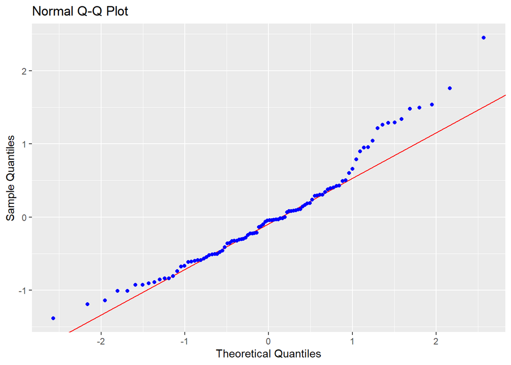

Cette conclusion est confirmée par l’examen de l’histogramme des résidus, qui met en évidence une distribution globalement centrée mais présentant des queues légèrement plus épaisses que celles d’une loi normale. Ainsi, si l’hypothèse de normalité est raisonnablement satisfaite pour la majorité des observations, elle semble fragilisée par le comportement des résidus les plus extrêmes.

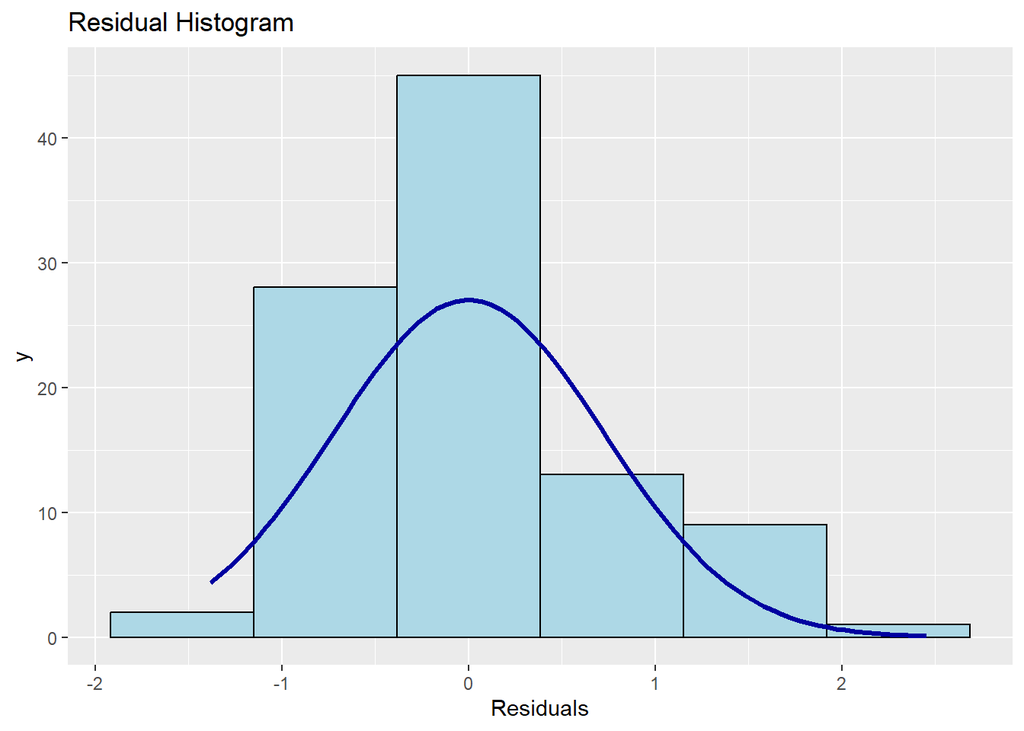

### 4.2.2 Identification des observations influentes

L’identification des observations influentes permet de déterminer si certains départements exercent une influence disproportionnée sur l’estimation des coefficients. L’analyse des différents graphiques de diagnostic met en évidence trois observations problématiques, correspondant aux départements 49 (Lozère), 88 (Haute-Vienne) et 97 (Martinique). Ces départements apparaissent de manière récurrente comme s’écartant du comportement moyen des résidus, contribuant ainsi aux déviations observées par rapport à la normalité.

Le calcul de la distance de Cook confirme cette observation. Trois départements se distinguent par une valeur relativement élevée de cette statistique : les départements 49 et 97, déjà identifiés précédemment, ainsi que le département 54 (Mayenne). Ces observations présentent un potentiel d’influence non négligeable sur les estimations du modèle.

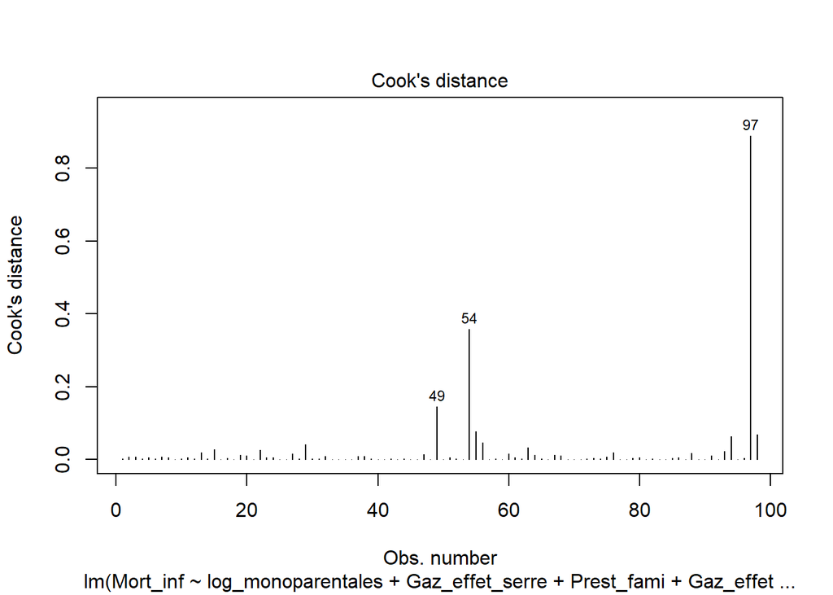

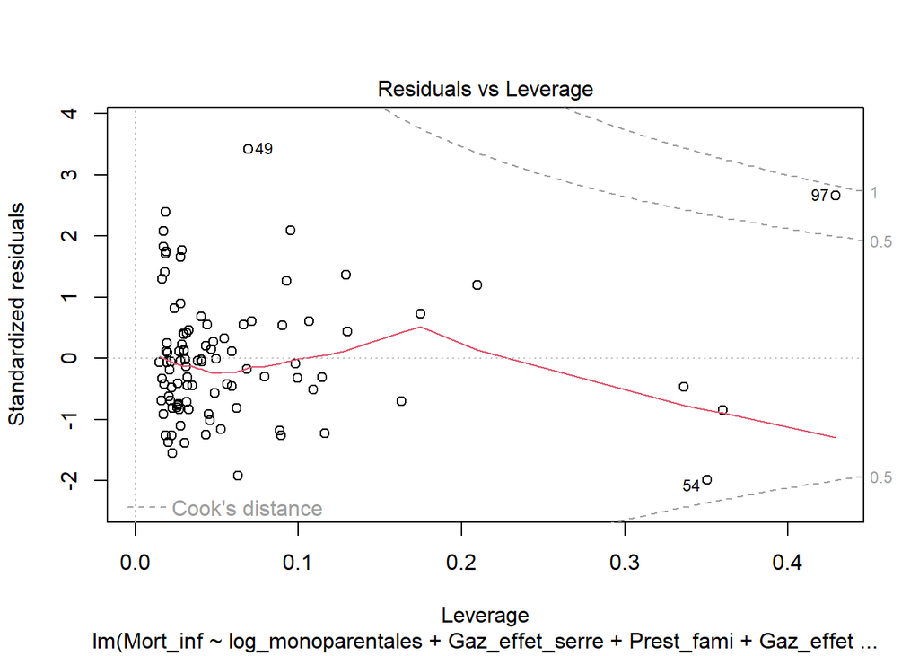

### 4.2.3 Tests de moyenne nulle et de normalité des résidus

Le modèle MCO suppose que les erreurs ont une espérance conditionnelle nulle. Cette hypothèse est testée à l’aide d’un test de Student, dont l’hypothèse nulle est $H_0 : \mathbb{E}(\epsilon_i) = 0$, contre l’alternative $H_1 :\mathbb{E}(\epsilon_i) \neq 0$.

Le test de Student appliqué aux résidus permet de vérifier l’hypothèse de moyenne nulle des erreurs. La moyenne estimée des résidus est numériquement est presque égale à zéro (=3.6×10−18) et la p-value du test est égale à 1. On ne peut donc pas rejeter l’hypothèse nulle selon laquelle l’espérance des résidus est nulle. Ce résultat est conforme aux propriétés théoriques de l’estimation par moindres carrés ordinaires en présence d’une constante.

La normalité des résidus est ensuite testée à l’aide du test de Shapiro–Wilk, dont l’hypothèse nulle est $H_0 : \epsilon_i \sim \mathcal{N}(0, \sigma^2)$. La p-value obtenue (0,0024) conduit à rejeter l’hypothèse de normalité. Ce résultat est cohérent avec les analyses graphiques et s’explique vraisemblablement par la présence de quelques observations extrêmes, plutôt que par une déformation générale de la distribution.

### 4.2.4 Hypothèse d’homoscedasticité

#### A) Analyse graphique de la variance des résidus

L’analyse de l’hypothèse d’homoscedasticité débute par un diagnostic graphique fondé sur le graphique Scale–Location, qui met en relation la racine carrée des résidus standardisés et les valeurs ajustées du modèle. Ce type de représentation permet d’identifier visuellement une éventuelle dépendance entre la dispersion des erreurs et le niveau de la variable expliquée.

En présence d’homoscedasticité, les résidus doivent être répartis de manière homogène autour d’une ligne de tendance approximativement horizontale. Dans notre cas, le graphique suggère une légère augmentation de la dispersion des résidus pour les valeurs ajustées les plus élevées, matérialisée par une inclinaison modérée de la courbe de lissage. Cette configuration pourrait indiquer une variance des erreurs légèrement croissante avec le niveau de la mortalité infantile prédite.

Toutefois, cette impression visuelle est fortement influencée par un nombre restreint d’observations atypiques, en particulier les départements 49, 88 et surtout 97, déjà identifiés comme influents dans les diagnostics précédents. En dehors de ces points extrêmes, la majorité des observations présente une dispersion relativement stable, ce qui invite à compléter l’analyse graphique par des tests statistiques formels.

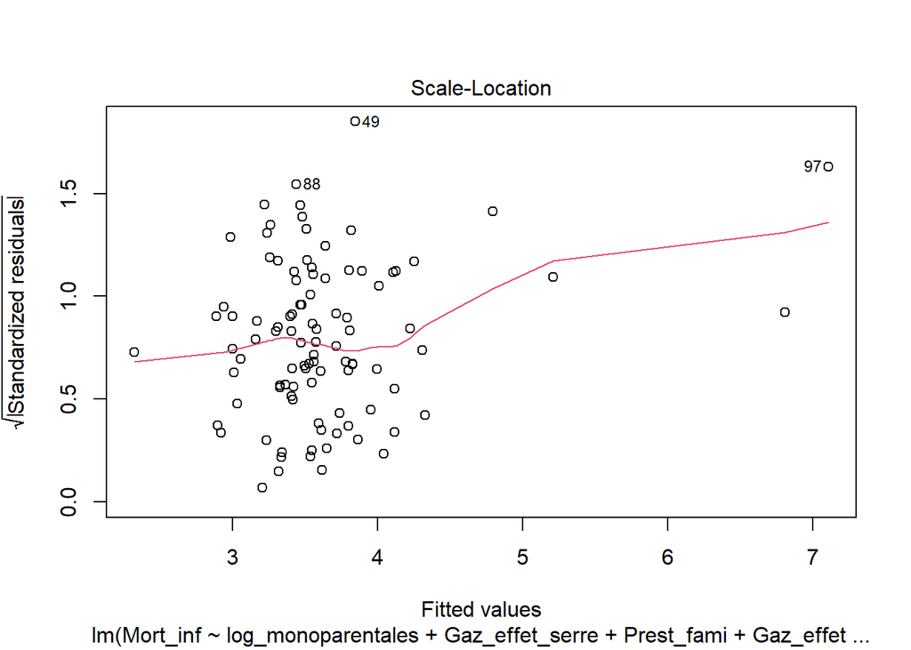

#### B) Analyse formelle : Tests statistiques

Afin de confirmer ou d’infirmer cette intuition visuelle, nous avons procédé à une batterie de tests formels. L’hypothèse d’homoscedasticité suppose que la variance des termes d’erreur est constante, quelle que soit la valeur des variables explicatives. Si cette hypothèse n’est pas respectée, les estimateurs MCO restent sans biais, mais les écarts-types estimés deviennent incorrects, ce qui affecte la validité des tests de Student et du test global de Fisher. Il est donc nécessaire de tester explicitement cette hypothèse à l’aide de tests formels.

On commence par le test de Breusch–Pagan, qui repose sur les hypothèses suivantes :

H₀ : la variance des résidus est constante (homoscédasticité),

H₁ : la variance des résidus dépend linéairement des variables explicatives.

Appliqué au modèle final, le test de Breusch–Pagan fournit une statistique de Breusch–Pagan égale à 8,72 pour 5 degrés de liberté, associée à une p-value de 0,1208. Cette p-value étant supérieure aux seuils de significativité, l’hypothèse nulle n’est pas rejetée. Il n’y a donc pas d’indice d’une hétéroscédasticité de forme linéaire dans le modèle.

Toutefois, le test de Breusch–Pagan est limité dans la mesure où il ne permet de détecter que des dépendances linéaires entre la variance des erreurs et les variables explicatives. Pour aller au-delà, on utilise des versions plus générales du test de White.

Cependant compte tenu de la taille limitée de l’échantillon (98 départements), un test de White complet mobilise un nombre élevé de degrés de liberté, ce qui peut réduire la puissance du test. C’est pour cette raison que le test de White restreint est également mobilisé, afin de disposer d’un diagnostic plus parcimonieux et mieux adapté aux données disponibles et que les les résultats du test de White complet doivent être interprétés avec prudence.

Ainsi le test de White restreint consiste à expliquer les carrés des résidus par les variables explicatives du modèle ainsi que par leurs carrés, sans introduire d’interactions croisées. Autrement dit, il permet de tester l’existence d’une hétéroscédasticité non linéaire, mais relativement simple, liée à l’amplitude des variables explicatives elles-mêmes. Les hypothèses testées sont les mêmes :

H₀ : homoscédasticité,

H₁ : hétéroscédasticité non linéaire.

Dans cette spécification, la statistique de Breusch–Pagan obtenue est de 8,84 avec 7 degrés de liberté, pour une p-value de 0,2646. Là encore, l’hypothèse nulle n’est pas rejetée, ce qui suggère que la variance des résidus ne dépend pas de manière quadratique des variables explicatives retenues.

Le test de White complet va encore plus loin en autorisant une forme très générale d’hétéroscédasticité. En plus des carrés des variables explicatives, il inclut l’ensemble des interactions croisées entre celles-ci. L’objectif est de détecter des structures complexes de variance conditionnelle, par exemple si la variabilité des erreurs dépend simultanément du niveau de deux variables. Ce test est volontairement large et peu parcimonieux, mais il permet de s’assurer qu’aucune forme systématique d’hétéroscédasticité n’est ignorée.

Les résultats du test de White complet indiquent une statistique de Breusch–Pagan de 10,93 pour 13 degrés de liberté, associée à une p-value de 0,6167. Cette p-value très élevée conduit clairement à ne pas rejeter l’hypothèse d’homoscedasticité, même dans une spécification extrêmement flexible.

Enfin, des tests de Goldfeld–Quandt sont réalisés afin de tester l’existence d’une hétéroscédasticité monotone, c’est-à-dire d’une variance des erreurs qui augmenterait avec le niveau d’une variable particulière. Ces tests sont appliqués successivement à la part des prestations familiales, à la part des familles monoparentales et aux émissions de gaz à effet de serre. Pour chacune de ces variables, les p-values obtenues sont largement supérieures aux seuils usuels, ce qui ne permet pas de rejeter l’hypothèse d’égalité des variances entre les sous-échantillons.

Pris dans leur ensemble, les différents tests formels conduisent à un diagnostic cohérent : aucune hétéroscédasticité statistiquement significative n’est mise en évidence dans le modèle final. Les écarts observés dans l’analyse graphique des résidus semblent davantage liés à la présence de quelques observations atypiques qu’à une violation structurelle de l’hypothèse d’homoscedasticité. Par souci de prudence, et afin de sécuriser l’inférence statistique, une estimation avec erreurs-types robustes est néanmoins présentée dans la section suivante.

#### C) Synthèse et réconciliation du diagnostic

Les résultats obtenus peuvent donner l’impression d’une divergence entre le diagnostic graphique et les tests formels. Le graphique Scale–Location suggère en effet une possible augmentation de la dispersion des résidus pour certaines valeurs ajustées, tandis que l’ensemble des tests statistiques — Breusch–Pagan, White restreint, White complet et Goldfeld–Quandt — ne conduit pas au rejet de l’hypothèse d’homoscedasticité.

Cette différence s’explique par la nature même des outils mobilisés. Le diagnostic graphique est un outil local, très sensible aux observations extrêmes et aux points à fort levier. Dans notre cas, quelques départements atypiques, notamment la Martinique (97), exercent une influence disproportionnée sur la forme de la courbe de lissage et peuvent donner l’illusion d’une hétéroscédasticité généralisée.

À l’inverse, les tests statistiques reposent sur une évaluation globale de la structure de la variance sur l’ensemble des 98 départements. La stabilité observée pour la majorité des observations conduit logiquement à ne pas détecter de violation significative de l’hypothèse d’homoscedasticité. Autrement dit, les écarts observés relèvent davantage de situations particulières que d’un problème structurel affectant l’ensemble du modèle.

#### Conclusion de la section 4.2.4

Pris dans leur ensemble, les diagnostics graphiques et les tests formels conduisent à un constat cohérent : aucune hétéroscédasticité systématique n’est mise en évidence dans le modèle final. Les légères irrégularités observées graphiquement s’expliquent principalement par la présence de quelques observations influentes plutôt que par une mauvaise spécification de la variance des erreurs.

Dans un souci de prudence méthodologique et afin de sécuriser l’inférence statistique, une estimation avec erreurs-types robustes est néanmoins présentée dans la section suivante. Cette étape permet de vérifier que les résultats du modèle ne dépendent pas de manière critique des hypothèses classiques de variance constante.

### 4.2.5 Estimation robuste à l’hétéroscédasticité

Même si les tests précédents ne mettent pas en évidence une hétéroscédasticité statistiquement significative, une estimation avec erreurs standards robustes de type White (HC1) est réalisée à titre de vérification. L’objectif n’est pas de proposer un nouveau modèle, mais de s’assurer que l’inférence statistique issue de l’estimation MCO ne dépend pas de manière critique des hypothèses relatives à la variance des erreurs.

Cette méthode repose sur les hypothèses suivantes :

H₀ : les estimateurs MCO sont valides et les erreurs standards classiques sont correctes ;

H₁ : la variance des erreurs peut être hétéroscédastique, rendant les erreurs standards MCO non fiables.

L’estimation robuste corrige uniquement la matrice de variance-covariance des estimateurs, sans modifier les coefficients estimés. Les résultats obtenus montrent que l’ensemble des coefficients conserve le même signe et des niveaux de significativité très proches de ceux présentés dans la section 4.1. Les variables centrales du modèle — notamment la part des familles monoparentales, les émissions de gaz à effet de serre, l’indicatrice de forte pollution et le terme d’interaction associé — demeurent statistiquement significatives aux seuils usuels.

Dans la mesure où l’analyse détaillée des coefficients a déjà été conduite dans la section 4.1, elle n’est pas reproduite ici. L’essentiel est que les conclusions économiques du modèle restent inchangées lorsque l’on relâche l’hypothèse d’homoscedasticité stricte.

Cette stabilité des résultats confirme la robustesse de l’inférence statistique et renforce la crédibilité des conclusions empiriques tirées du modèle final.

```
##
## t test of coefficients:
##
##                                        Estimate Std. Error t value  Pr(>|t|)
## (Intercept)                           -6.992218   2.013956 -3.4719 0.0007892
## log_monoparentales                     3.243702   0.693885  4.6747 1.005e-05
## Gaz_effet_serre                        0.154007   0.064485  2.3882 0.0189724
## Prest_fami                             0.355261   0.188280  1.8869 0.0623301
## Gaz_effet_serre_Q3                     8.192952   3.016969  2.7156 0.0079011
## log_monoparentales:Gaz_effet_serre_Q3 -3.173785   1.135576 -2.7949 0.0063191
##
## (Intercept)                           ***
## log_monoparentales                    ***
## Gaz_effet_serre                       *
## Prest_fami                            .
## Gaz_effet_serre_Q3                    **
## log_monoparentales:Gaz_effet_serre_Q3 **
## ---
## Signif. codes:  0 '***' 0.001 '**' 0.01 '*' 0.05 '.' 0.1 ' ' 1
```

### 4.2.6 Conclusion

## **4.3 Analyses complémentaires**

Cette section ne vise pas à proposer de nouvelles estimations, mais à discuter de manière critique les choix de modélisation retenus, ainsi que les limites inhérentes aux données et à la méthode employée. Elle permet d’identifier les principaux biais potentiels et d’ouvrir des pistes d’amélioration pour de futures analyses.

### 4.3.1 Transformations de variables et spécification fonctionnelle

Le modèle repose sur une spécification essentiellement linéaire, à l’exception de la transformation logarithmique appliquée à la part des familles monoparentales et de l’introduction d’une variable indicatrice pour les départements les plus pollués. Ces choix sont cohérents avec la structure des données et permettent une interprétation économique claire.

Néanmoins, cette spécification implique l’hypothèse que les relations entre les variables explicatives et la mortalité infantile sont, en moyenne, linéaires à l’intérieur de chaque régime défini par le niveau de pollution. Or, il est possible que certains effets soient non linéaires, par exemple si l’impact de la pollution ou des facteurs sociaux devient plus marqué au-delà de certains seuils. Faute d’un échantillon plus large, l’introduction systématique de formes fonctionnelles plus flexibles (polynômes, splines) aurait cependant réduit la précision des estimations et n’a pas été retenue.

Ainsi, le modèle privilégie la lisibilité et la parcimonie, au prix d’une possible simplification des mécanismes sous-jacents.

### 4.3.2 Effets de structure et hétérogénéité non observée

L’introduction d’une variable indicatrice associée au troisième quartile des émissions de gaz à effet de serre peut être interprétée comme une manière simple de capter un changement structurel entre départements faiblement et fortement pollués. Ce choix permet de mettre en évidence une hétérogénéité des relations, sans recourir à des méthodes plus lourdes difficilement applicables dans un cadre transversal.

Cependant, cette approche suppose que la rupture est bien localisée à ce seuil particulier, ce qui reste un choix en partie arbitraire. D’autres découpages de la distribution ou des approches continues auraient pu conduire à des résultats légèrement différents. De plus, l’analyse ne permet pas d’identifier de véritables ruptures structurelles au sens économétrique du terme, celles-ci étant généralement étudiées dans des cadres temporels ou quasi-expérimentaux.

### 4.3.3 Biais de variables omises

Une limite importante du modèle réside dans le risque de biais de variables omises. La mortalité infantile est influencée par de nombreux facteurs non observés dans les données disponibles, tels que l’accès aux soins de santé, la qualité des infrastructures hospitalières, les comportements de santé, ou encore certaines caractéristiques environnementales plus fines que les seules émissions de gaz à effet de serre.

Si ces facteurs non observés sont corrélés à la fois avec les variables explicatives incluses dans le modèle (par exemple les caractéristiques socio-économiques ou le niveau de pollution) et avec la mortalité infantile, les coefficients estimés peuvent être biaisés. Les résultats doivent donc être interprétés comme des associations conditionnelles, et non comme des effets causaux stricts.

### 4.3.4 Biais de simultanéité et endogénéité potentielle

Le modèle repose implicitement sur l’hypothèse d’exogénéité des variables explicatives. Or, certaines relations peuvent être bidirectionnelles. Par exemple, les politiques sociales, mesurées ici par la part des prestations familiales, peuvent à la fois influencer la mortalité infantile et être ajustées en réponse à des situations sociales ou sanitaires plus dégradées.

De même, les émissions de gaz à effet de serre sont liées au niveau d’activité économique, qui peut également être corrélé à d’autres déterminants non observés de la mortalité infantile. En l’absence d’instruments valides ou de données longitudinales, il n’est pas possible de traiter formellement ces problèmes d’endogénéité dans le cadre de cette étude.

### 4.3.5 Erreurs de mesure et agrégation spatiale

Les variables utilisées sont mesurées au niveau départemental, ce qui implique une agrégation de phénomènes individuels potentiellement très hétérogènes. Cette agrégation peut masquer des disparités internes importantes et introduire des erreurs de mesure, notamment pour des variables comme la pollution ou les prestations sociales, qui ne reflètent qu’imparfaitement l’exposition ou la situation réelle des individus concernés.

Par ailleurs, certaines erreurs de mesure peuvent être corrélées entre variables, ce qui complique encore l’interprétation des coefficients estimés.

### Lecture générale

Dans l’ensemble, le modèle proposé permet de mettre en évidence des régularités empiriques intéressantes et statistiquement robustes, mais il doit être interprété avec prudence. Les résultats ne constituent pas des preuves causales, mais des associations conditionnelles éclairantes, qui soulignent l’importance des interactions entre facteurs sociaux et environnementaux dans l’analyse de la mortalité infantile.

# **5 Conclusion générale et perspectives**

# **6 Bibliographie - Source des données**